# Climate and Energy Data Processing

Data Analysis Team

May 23, 2025

# Overview

This document processes and analyzes climate and energy data from two main sources:

1. **Our World in Data (OWID)** - Energy consumption data by source
2. **Climate Watch** - Emissions data

The script filters the data for selected years, joins the datasets, performs quality checks, and creates visualizations to help understand the relationship between energy consumption patterns and emissions.

## Load Required Libraries

```r
# Required libraries
library(readr)
library(dplyr)
library(tidyr)
library(jsonlite)
library(ggplot2)
library(gridExtra)
```

## Set Parameters

We can easily modify the year range by changing these variables:

```r
# Year range variables for easy modification
START_YEAR <- 2015
END_YEAR <- 2022
```

# Data Loading and Initial Exploration

## Read Data Files

```r
# Step 1: Read the CSV files
cat("Reading CSV files...\n")
```

```
## Reading CSV files...
```

```r
owid_data <- read_csv("owid-energy-data.csv", show_col_types = FALSE)
cw_data <- read_csv("climatewatch__emissions.csv", show_col_types = FALSE)

# Check if files were read successfully
cat("OWID data rows:", nrow(owid_data), "columns:", ncol(owid_data), "\n")
```

```
## OWID data rows: 21812 columns: 129
```

```r
cat("Climate Watch data rows:", nrow(cw_data), "columns:", ncol(cw_data), "\n")
```

```
## Climate Watch data rows: 22920 columns: 8
```

Here’s a sample of the Climate Watch data:

```r
print(cw_data)
```

```
## # A tibble: 22,920 × 8
##         id iso_code3 country data_source sector            gas   unit  emissions
##      <dbl> <chr>     <chr>   <chr>       <chr>             <chr> <chr> <chr>
##  1 1112029 ABW       Aruba   PIK         Energy            CH4   MtCO… [{'year'…
##  2 1112030 ABW       Aruba   PIK         Energy            CO2   MtCO… [{'year'…
##  3 1112031 ABW       Aruba   PIK         Energy            KYOT… MtCO… [{'year'…
##  4 1112032 ABW       Aruba   PIK         Energy            N2O   MtCO… [{'year'…
##  5 1112033 ABW       Aruba   PIK         Industrial Proce… CO2   MtCO… [{'year'…
##  6 1112034 ABW       Aruba   PIK         Industrial Proce… KYOT… MtCO… [{'year'…
##  7 1112035 ABW       Aruba   PIK         Industrial Proce… N2O   MtCO… [{'year'…
##  8 1112036 ABW       Aruba   PIK         Other             KYOT… MtCO… [{'year'…
##  9 1112037 ABW       Aruba   PIK         Other             N2O   MtCO… [{'year'…
## 10 1112038 ABW       Aruba   PIK         Total excluding … CH4   MtCO… [{'year'…
## # ℹ 22,910 more rows
```

# Data Processing

## Process OWID Energy Data

We filter the OWID data for the selected years and calculate energy share percentages:

```r
# Step 2: Filter OWID data for fossil and low carbon energy related columns and years
cat(sprintf("Filtering data for years %d to %d...\n", START_YEAR, END_YEAR))
```

```
## Filtering data for years 2015 to 2022...
```

```r
owid_filtered <- owid_data %>%
  filter(year >= START_YEAR, year <= END_YEAR) %>%
  select(
    country, year, iso_code, population, gdp,
    # Energy consumption columns (instead of share columns)
    primary_energy_consumption,
    # Fossil fuel related
    fossil_fuel_consumption, coal_consumption, oil_consumption, gas_consumption,
    # Low carbon energy related
    low_carbon_consumption, nuclear_consumption,
    # Renewable energy
    renewables_consumption, hydro_consumption, solar_consumption,
    wind_consumption, biofuel_consumption, other_renewable_consumption
  ) %>%
  # Calculate share percentages based on consumption values
  # Handle cases where primary_energy_consumption is NA or 0 to avoid division by zero
  mutate(
    # First replace 0 values with NA in primary_energy_consumption to avoid division by zero
    primary_energy_consumption = ifelse(primary_energy_consumption == 0, NA, primary_energy_consumption),

    # Fossil fuel shares - use ifelse to check for NA or zero in denominator
    calc_fossil_share_energy = ifelse(!is.na(primary_energy_consumption) & primary_energy_consumption > 0,
                                      (fossil_fuel_consumption / primary_energy_consumption) * 100, NA),
    calc_coal_share_energy = ifelse(!is.na(primary_energy_consumption) & primary_energy_consumption > 0,
                                    (coal_consumption / primary_energy_consumption) * 100, NA),
    calc_oil_share_energy = ifelse(!is.na(primary_energy_consumption) & primary_energy_consumption > 0,
                                   (oil_consumption / primary_energy_consumption) * 100, NA),
    calc_gas_share_energy = ifelse(!is.na(primary_energy_consumption) & primary_energy_consumption > 0,
                                   (gas_consumption / primary_energy_consumption) * 100, NA),

    # Low carbon shares
    calc_low_carbon_share_energy = ifelse(!is.na(primary_energy_consumption) & primary_energy_consumption > 0,
                                          (low_carbon_consumption / primary_energy_consumption) * 100, NA),
    calc_nuclear_share_energy = ifelse(!is.na(primary_energy_consumption) & primary_energy_consumption > 0,
                                       (nuclear_consumption / primary_energy_consumption) * 100, NA),

    # Renewable shares
    calc_renewables_share_energy = ifelse(!is.na(primary_energy_consumption) & primary_energy_consumption > 0,
                                          (renewables_consumption / primary_energy_consumption) * 100, NA),
    calc_hydro_share_energy = ifelse(!is.na(primary_energy_consumption) & primary_energy_consumption > 0,
                                     (hydro_consumption / primary_energy_consumption) * 100, NA),
    calc_solar_share_energy = ifelse(!is.na(primary_energy_consumption) & primary_energy_consumption > 0,
                                     (solar_consumption / primary_energy_consumption) * 100, NA),
    calc_wind_share_energy = ifelse(!is.na(primary_energy_consumption) & primary_energy_consumption > 0,
                                    (wind_consumption / primary_energy_consumption) * 100, NA),
    calc_biofuel_share_energy = ifelse(!is.na(primary_energy_consumption) & primary_energy_consumption > 0,
                                       (biofuel_consumption / primary_energy_consumption) * 100, NA),
    calc_other_renewable_share_energy = ifelse(!is.na(primary_energy_consumption) & primary_energy_consumption > 0,
                                               (other_renewable_consumption / primary_energy_consumption) * 100, NA)
  )
```

### Examine the Processed OWID Energy Data

Let’s examine the processed OWID energy data to get a better understanding of its structure and contents:

```r
# Filter out non-country entities (regions, continents, etc.)
# Check if a proper country by looking for ISO code (all countries have ISO codes)
owid_filtered <- owid_filtered %>%
  filter(!is.na(iso_code))

# Display sample of the filtered OWID data
cat("\nSample of filtered OWID data (first 5 rows):\n")
```

```
##
## Sample of filtered OWID data (first 5 rows):
```

```r
print(head(owid_filtered, 5))
```

```
## # A tibble: 5 × 30
##   country      year iso_code population         gdp primary_energy_consumption
##   <chr>       <dbl> <chr>         <dbl>       <dbl>                      <dbl>
## 1 Afghanistan  2015 AFG        33753500 62783393792                       32.7
## 2 Afghanistan  2016 AFG        34636212 64372215808                       29.9
## 3 Afghanistan  2017 AFG        35643420 65169281024                       29.6
## 4 Afghanistan  2018 AFG        36686788 65996738560                       33.9
## 5 Afghanistan  2019 AFG        37769496 73085706240                       30.3
## # ℹ 24 more variables: fossil_fuel_consumption <dbl>, coal_consumption <dbl>,
## #   oil_consumption <dbl>, gas_consumption <dbl>, low_carbon_consumption <dbl>,
## #   nuclear_consumption <dbl>, renewables_consumption <dbl>,
## #   hydro_consumption <dbl>, solar_consumption <dbl>, wind_consumption <dbl>,
## #   biofuel_consumption <dbl>, other_renewable_consumption <dbl>,
## #   calc_fossil_share_energy <dbl>, calc_coal_share_energy <dbl>,
## #   calc_oil_share_energy <dbl>, calc_gas_share_energy <dbl>, …
```

```r
# Count the number of countries in the filtered data
cat("\nNumber of countries in filtered OWID data:", length(unique(owid_filtered$country)), "\n")
```

```
##
## Number of countries in filtered OWID data: 220
```

## Process Climate Watch Emissions Data

We process the Climate Watch emissions data, paying special attention to properly parse JSON content:

```r
# Step 3: Process Climate Watch data
# First check the structure of the emissions column
if("emissions" %in% colnames(cw_data)) {
  # Pre-filter the cw_data for sector "Energy" and gas "All GHG" if those columns exist
  if(all(c("sector", "gas") %in% colnames(cw_data))) {
    cat("Pre-filtering Climate Watch data for Energy sector and All GHG gas...\n")
    cw_data <- cw_data %>%
      filter(sector == "Energy", gas == "All GHG")
    cat("Filtered data size: ", nrow(cw_data), "rows\n")
  }

  # Unnest the emissions column
  # Function to safely parse JSON with error handling
  safe_parse_json <- function(json_string) {
    # Replace single quotes with double quotes and None with null
    json_string <- gsub("'", "\"", json_string)
    json_string <- gsub("\\bNone\\b", "null", json_string)
    tryCatch(
      jsonlite::fromJSON(json_string, simplifyVector = TRUE),
      error = function(e) {
        message("Error parsing JSON for string: ", substr(json_string, 1, 50), "...")
        message("Error message: ", e$message)
        return(NULL) # Return NULL for failed parsing
      }
    )
  }

  # Parse emissions column and unnest
  cat("Parsing JSON emissions data...\n")
  cw_data_unnested <- cw_data %>%
    mutate(emissions = lapply(emissions, safe_parse_json)) %>%
    filter(!sapply(emissions, is.null)) %>% # Remove rows with failed parsing
    unnest(cols = emissions, names_repair = "minimal")

  # Print distinct values and counts
  cat("\nDistinct values in 'gas' column:\n")
  print(unique(cw_data_unnested$gas))
  cat("\nCount of distinct gas values:", length(unique(cw_data_unnested$gas)), "\n")

  cat("\nDistinct values in 'sector' column:\n")
  print(unique(cw_data_unnested$sector))
  cat("\nCount of distinct sector values:", length(unique(cw_data_unnested$sector)), "\n")
  cat("\nNumber of distinct countries:", length(unique(cw_data_unnested$country)), "\n")
    # Filter for Energy sector and All GHG gas, and years between START_YEAR-END_YEAR
  cw_filtered <- cw_data_unnested %>%
    filter(sector == "Energy", gas == "All GHG", year >= START_YEAR, year <= END_YEAR) %>%
    select(country, iso_code3, year, value) %>%
    rename(iso_code = iso_code3, emissions = value)

  # Filter out non-country entities (ensure valid ISO codes)
  cw_filtered <- cw_filtered %>%
    filter(!is.na(iso_code), iso_code != "")

} else {
  stop("Column 'emissions' not found in cw_data. Available columns: ", paste(colnames(cw_data), collapse = ", "))
}
```

### Examine the Processed Climate Watch Data

```r
# Filter out non-country entities (already done above, showing results here)
cat("\nSample of filtered Climate Watch data (first 5 rows):\n")
```

```
##
## Sample of filtered Climate Watch data (first 5 rows):
```

```r
print(head(cw_filtered, 5))
```

```
## # A tibble: 5 × 4
##   country     iso_code  year emissions
##   <chr>       <chr>    <int>     <dbl>
## 1 Afghanistan AFG       2015      12.0
## 2 Afghanistan AFG       2016      11.2
## 3 Afghanistan AFG       2017      12.0
## 4 Afghanistan AFG       2018      12.9
## 5 Afghanistan AFG       2019      13.1
```

```r
# Count the number of countries and years in the filtered data
cat("\nNumber of valid countries in filtered data:", length(unique(cw_filtered$country)), "\n")
```

```
##
## Number of valid countries in filtered data: 245
```

```r
cat("Number of valid ISO codes in filtered data:", length(unique(cw_filtered$iso_code)), "\n")
```

```
## Number of valid ISO codes in filtered data: 246
```

```r
cat("Year range in filtered data:", min(cw_filtered$year, na.rm = TRUE), "to",
    max(cw_filtered$year, na.rm = TRUE), "\n")
```

```
## Year range in filtered data: 2015 to 2022
```

```r
cat("Total rows in filtered data:", nrow(cw_filtered), "\n")
```

```
## Total rows in filtered data: 1866
```

```r
# Check for any rows with empty or NA ISO codes that might have slipped through
missing_iso_count <- sum(is.na(cw_filtered$iso_code) | cw_filtered$iso_code == "")
if(missing_iso_count > 0) {
  cat("\nWARNING: There are still", missing_iso_count, "rows with missing ISO codes\n")
  print(cw_filtered %>% filter(is.na(iso_code) | iso_code == "") %>% select(country) %>% distinct())
}
```

## Ensure Data Types and Check Year Ranges

```r
# Step 4: Ensure year column is numeric
owid_filtered <- owid_filtered %>% mutate(year = as.numeric(year))
cw_filtered <- cw_filtered %>% mutate(year = as.numeric(year))
```

# Data Quality Analysis

## Missing Values Analysis - OWID Dataset

```r
# Calculate and print missing values in OWID dataset
cat("\n----- OWID Missing Values Analysis -----\n")
```

```
##
## ----- OWID Missing Values Analysis -----
```

```r
owid_missing <- colSums(is.na(owid_filtered))
owid_missing_percent <- (owid_missing / nrow(owid_filtered)) * 100
owid_missing_df <- data.frame(
  Column = names(owid_missing),
  Missing_Count = owid_missing,
  Missing_Percent = round(owid_missing_percent, 2)
)
# Only show columns with at least one missing value
owid_missing_filtered <- owid_missing_df[owid_missing_df$Missing_Count > 0, ]
print(owid_missing_filtered[order(-owid_missing_filtered$Missing_Percent), ])
```

```
##                                                              Column
## biofuel_consumption                             biofuel_consumption
## calc_biofuel_share_energy                 calc_biofuel_share_energy
## low_carbon_consumption                       low_carbon_consumption
## renewables_consumption                       renewables_consumption
## hydro_consumption                                 hydro_consumption
## calc_low_carbon_share_energy           calc_low_carbon_share_energy
## calc_renewables_share_energy           calc_renewables_share_energy
## calc_hydro_share_energy                     calc_hydro_share_energy
## fossil_fuel_consumption                     fossil_fuel_consumption
## calc_fossil_share_energy                   calc_fossil_share_energy
## gas_consumption                                     gas_consumption
## calc_gas_share_energy                         calc_gas_share_energy
## coal_consumption                                   coal_consumption
## calc_coal_share_energy                       calc_coal_share_energy
## oil_consumption                                     oil_consumption
## solar_consumption                                 solar_consumption
## wind_consumption                                   wind_consumption
## other_renewable_consumption             other_renewable_consumption
## calc_oil_share_energy                         calc_oil_share_energy
## calc_solar_share_energy                     calc_solar_share_energy
## calc_wind_share_energy                       calc_wind_share_energy
## calc_other_renewable_share_energy calc_other_renewable_share_energy
## calc_nuclear_share_energy                 calc_nuclear_share_energy
## nuclear_consumption                             nuclear_consumption
## gdp                                                             gdp
## primary_energy_consumption               primary_energy_consumption
## population                                               population
##                                   Missing_Count Missing_Percent
## biofuel_consumption                        1286           73.49
## calc_biofuel_share_energy                  1286           73.49
## low_carbon_consumption                     1174           67.09
## renewables_consumption                     1174           67.09
## hydro_consumption                          1174           67.09
## calc_low_carbon_share_energy               1174           67.09
## calc_renewables_share_energy               1174           67.09
## calc_hydro_share_energy                    1174           67.09
## fossil_fuel_consumption                    1156           66.06
## calc_fossil_share_energy                   1156           66.06
## gas_consumption                            1143           65.31
## calc_gas_share_energy                      1143           65.31
## coal_consumption                           1132           64.69
## calc_coal_share_energy                     1132           64.69
## oil_consumption                            1119           63.94
## solar_consumption                          1119           63.94
## wind_consumption                           1119           63.94
## other_renewable_consumption                1119           63.94
## calc_oil_share_energy                      1119           63.94
## calc_solar_share_energy                    1119           63.94
## calc_wind_share_energy                     1119           63.94
## calc_other_renewable_share_energy          1119           63.94
## calc_nuclear_share_energy                   936           53.49
## nuclear_consumption                         901           51.49
## gdp                                         430           24.57
## primary_energy_consumption                  186           10.63
## population                                   14            0.80
```

```r
# Check missing values by country and year
# Calculate missing values by country and year for important columns
check_missing_by_country_year <- function(data, column_name) {
  missing_by_country_year <- data %>%
    group_by(country, year) %>%
    summarize(
      missing_count = sum(is.na(!!sym(column_name))),
      total_rows = n(),
      missing_percent = (missing_count / total_rows) * 100,
      .groups = "drop"
    ) %>%
    filter(missing_count > 0) %>%
    arrange(desc(missing_percent), country, year)

  return(missing_by_country_year)
}

# Check missing values for primary energy consumption
missing_primary_energy <- check_missing_by_country_year(owid_filtered, "primary_energy_consumption")
cat("\nCountries and years with missing primary energy consumption data:\n")
```

```
##
## Countries and years with missing primary energy consumption data:
```

```r
print(head(missing_primary_energy, 10))  # Show only the top 10 rows
```

```
## # A tibble: 10 × 5
##    country              year missing_count total_rows missing_percent
##    <chr>               <dbl>         <int>      <int>           <dbl>
##  1 Afghanistan          2022             1          1             100
##  2 Albania              2022             1          1             100
##  3 American Samoa       2022             1          1             100
##  4 Angola               2022             1          1             100
##  5 Antigua and Barbuda  2022             1          1             100
##  6 Armenia              2022             1          1             100
##  7 Aruba                2022             1          1             100
##  8 Bahamas              2022             1          1             100
##  9 Bahrain              2022             1          1             100
## 10 Barbados             2022             1          1             100
```

```r
# Check missing values for fossil fuel consumption
missing_fossil_fuel <- check_missing_by_country_year(owid_filtered, "fossil_fuel_consumption")
cat("\nCountries and years with missing fossil fuel consumption data:\n")
```

```
##
## Countries and years with missing fossil fuel consumption data:
```

```r
print(head(missing_fossil_fuel, 10))  # Show only the top 10 rows
```

```
## # A tibble: 10 × 5
##    country      year missing_count total_rows missing_percent
##    <chr>       <dbl>         <int>      <int>           <dbl>
##  1 Afghanistan  2015             1          1             100
##  2 Afghanistan  2016             1          1             100
##  3 Afghanistan  2017             1          1             100
##  4 Afghanistan  2018             1          1             100
##  5 Afghanistan  2019             1          1             100
##  6 Afghanistan  2020             1          1             100
##  7 Afghanistan  2021             1          1             100
##  8 Afghanistan  2022             1          1             100
##  9 Albania      2015             1          1             100
## 10 Albania      2016             1          1             100
```

```r
# Get the total unique countries in OWID dataset
owid_countries_count <- owid_filtered %>%
  filter(!is.na(iso_code)) %>%
  pull(iso_code) %>%
  unique() %>%
  length()

# Check coverage completeness by year for key metrics
owid_coverage_by_year <- owid_filtered %>%
  group_by(year) %>%
  summarize(
    total_countries = n_distinct(iso_code),
    countries_with_population = n_distinct(iso_code[!is.na(population)]),
    countries_with_gdp = n_distinct(iso_code[!is.na(gdp)]),
    countries_with_energy = n_distinct(iso_code[!is.na(primary_energy_consumption)]),
    countries_with_fossil = n_distinct(iso_code[!is.na(fossil_fuel_consumption)]),
    countries_with_renewables = n_distinct(iso_code[!is.na(renewables_consumption)]),
    population_coverage = (countries_with_population / owid_countries_count) * 100,
    gdp_coverage = (countries_with_gdp / owid_countries_count) * 100,
    energy_coverage = (countries_with_energy / owid_countries_count) * 100,
    fossil_coverage = (countries_with_fossil / owid_countries_count) * 100,
    renewables_coverage = (countries_with_renewables / owid_countries_count) * 100,
    .groups = "drop"
  )

cat("\nOWID Coverage completeness by year (against maximum", owid_countries_count, "countries):\n")
```

```
##
## OWID Coverage completeness by year (against maximum 220 countries):
```

```r
print(head(owid_coverage_by_year))
```

```
## # A tibble: 6 × 12
##    year total_countries countries_with_population countries_with_gdp
##   <dbl>           <int>                     <int>              <int>
## 1  2015             220                       218                165
## 2  2016             220                       218                165
## 3  2017             220                       218                165
## 4  2018             220                       218                165
## 5  2019             220                       218                165
## 6  2020             220                       218                165
## # ℹ 8 more variables: countries_with_energy <int>, countries_with_fossil <int>,
## #   countries_with_renewables <int>, population_coverage <dbl>,
## #   gdp_coverage <dbl>, energy_coverage <dbl>, fossil_coverage <dbl>,
## #   renewables_coverage <dbl>
```

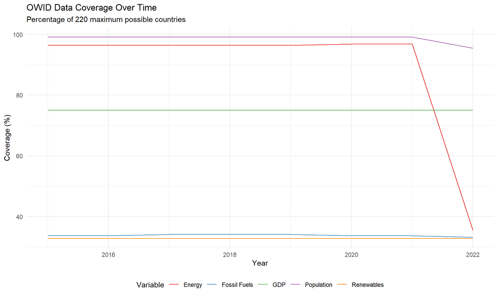

```r
# Visualize OWID data coverage over time
ggplot(owid_coverage_by_year, aes(x = year)) +
  geom_line(aes(y = energy_coverage, color = "Energy")) +
  geom_line(aes(y = fossil_coverage, color = "Fossil Fuels")) +
  geom_line(aes(y = renewables_coverage, color = "Renewables")) +
  geom_line(aes(y = population_coverage, color = "Population")) +
  geom_line(aes(y = gdp_coverage, color = "GDP")) +
  labs(title = "OWID Data Coverage Over Time",
       subtitle = paste("Percentage of", owid_countries_count, "maximum possible countries"),
       x = "Year",
       y = "Coverage (%)",
       color = "Variable") +
  theme_minimal() +
  scale_color_brewer(palette = "Set1") +
  theme(legend.position = "bottom")
```

## Missing Values Analysis - Climate Watch Dataset

```r
cat("\nClimate Watch data year range (after filtering):", min(cw_filtered$year, na.rm = TRUE), "to",
    max(cw_filtered$year, na.rm = TRUE), "\n")
```

```
##
## Climate Watch data year range (after filtering): 2015 to 2022
```

```r
cat("Climate Watch filtered data rows:", nrow(cw_filtered), "\n")
```

```
## Climate Watch filtered data rows: 1866
```

```r
# Calculate and print missing values in Climate Watch dataset
cat("\n----- Climate Watch Missing Values Analysis -----\n")
```

```
##
## ----- Climate Watch Missing Values Analysis -----
```

```r
cw_missing <- colSums(is.na(cw_filtered))
cw_missing_percent <- (cw_missing / nrow(cw_filtered)) * 100
cw_missing_df <- data.frame(
  Column = names(cw_missing),
  Missing_Count = cw_missing,
  Missing_Percent = round(cw_missing_percent, 2)
)
# Only show columns with at least one missing value
cw_missing_filtered <- cw_missing_df[cw_missing_df$Missing_Count > 0, ]
print(cw_missing_filtered[order(-cw_missing_filtered$Missing_Percent), ])
```

```
## [1] Column          Missing_Count   Missing_Percent
## <0 rows> (or 0-length row.names)
```

```r
# Check missing values by country and year for emissions
missing_emissions <- check_missing_by_country_year(cw_filtered, "emissions")
cat("\nCountries and years with missing emissions data:\n")
```

```
##
## Countries and years with missing emissions data:
```

```r
print(head(missing_emissions, 10))  # Show only the top 10 rows
```

```
## # A tibble: 0 × 5
## # ℹ 5 variables: country <chr>, year <dbl>, missing_count <int>,
## #   total_rows <int>, missing_percent <dbl>
```

```r
# Get the total unique countries in Climate Watch dataset
cw_countries_count <- cw_filtered %>%
  filter(!is.na(iso_code)) %>%
  pull(iso_code) %>%
  unique() %>%
  length()

# Check coverage completeness by year
cw_coverage_by_year <- cw_filtered %>%
  group_by(year) %>%
  summarize(
    total_countries = n_distinct(iso_code),
    countries_with_emissions = n_distinct(iso_code[!is.na(emissions)]),
    # Calculate coverage against year's total and maximum possible
    year_coverage_percent = (countries_with_emissions / total_countries) * 100,
    max_coverage_percent = (countries_with_emissions / cw_countries_count) * 100,
    .groups = "drop"
  )

cat("\nClimate Watch coverage completeness by year (against maximum", cw_countries_count, "countries):\n")
```

```
##
## Climate Watch coverage completeness by year (against maximum 246 countries):
```

```r
print(cw_coverage_by_year)
```

```
## # A tibble: 8 × 5
##    year total_countries countries_with_emissions year_coverage_percent
##   <dbl>           <int>                    <int>                 <dbl>
## 1  2015             246                      246                   100
## 2  2016             246                      246                   100
## 3  2017             246                      246                   100
## 4  2018             246                      246                   100
## 5  2019             246                      246                   100
## 6  2020             246                      246                   100
## 7  2021             195                      195                   100
## 8  2022             195                      195                   100
## # ℹ 1 more variable: max_coverage_percent <dbl>
```

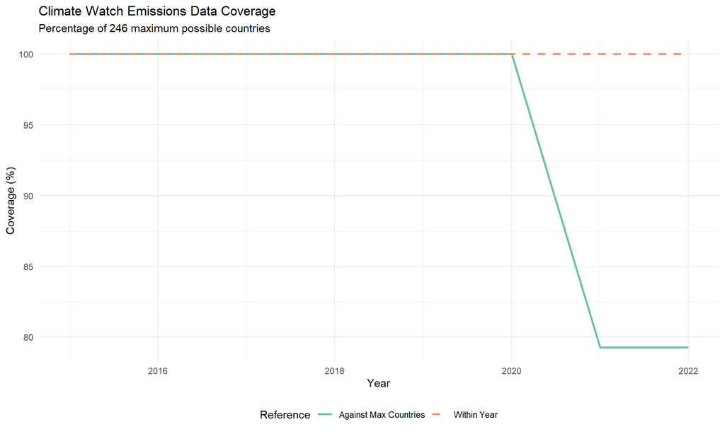

```r
# Visualize Climate Watch data coverage over time
ggplot(cw_coverage_by_year, aes(x = year)) +
  geom_line(aes(y = max_coverage_percent, color = "Against Max Countries"), size = 1) +
  geom_line(aes(y = year_coverage_percent, color = "Within Year"), size = 1, linetype = "dashed") +
  labs(title = "Climate Watch Emissions Data Coverage",
       subtitle = paste("Percentage of", cw_countries_count, "maximum possible countries"),
       x = "Year",
       y = "Coverage (%)",
       color = "Reference") +
  theme_minimal() +
  scale_color_brewer(palette = "Set2") +
  theme(legend.position = "bottom")
```

# Save Filtered Datasets

Create output filenames with the year range and save the filtered datasets for future use:

```r
# Create output filenames with year range
owid_output_file <- sprintf("owid_filtered_%d_%d.csv", START_YEAR, END_YEAR)
cw_output_file <- sprintf("cw_filtered_%d_%d.csv", START_YEAR, END_YEAR)
merged_output_file <- sprintf("energy_emissions_merged_%d_%d.csv", START_YEAR, END_YEAR)

# Optionally save the filtered datasets before merging
write_csv(owid_filtered, owid_output_file)
write_csv(cw_filtered, cw_output_file)
cat(sprintf("\nFiltered datasets saved as:\n- %s\n- %s\n", owid_output_file, cw_output_file))
```

```
##
## Filtered datasets saved as:
## - owid_filtered_2015_2022.csv
## - cw_filtered_2015_2022.csv
```

# Merge Datasets

```r
# Step 5: Merge datasets
# First, analyze potential country name mismatches
owid_countries <- owid_filtered %>%
  select(country, iso_code) %>%
  distinct()

cw_countries <- cw_filtered %>%
  select(country, iso_code) %>%
  distinct()

# Check for ISO codes that appear in both datasets but with different country names
country_name_variants <- full_join(
  owid_countries,
  cw_countries,
  by = "iso_code"
) %>%
  filter(!is.na(iso_code), country.x != country.y) %>%
  rename(owid_country = country.x, cw_country = country.y)

cat("\nISO codes with different country names in the two datasets:\n")
```

```
##
## ISO codes with different country names in the two datasets:
```

```r
print(country_name_variants)
```

```
## # A tibble: 6 × 3
##   owid_country                 iso_code cw_country
##   <chr>                        <chr>    <chr>
## 1 Cape Verde                   CPV      Cabo Verde
## 2 Cote d'Ivoire                CIV      Côte d'Ivoire
## 3 Czechia                      CZE      Czech Republic
## 4 Democratic Republic of Congo COD      Democratic Republic of the Congo
## 5 Micronesia (country)         FSM      Micronesia
## 6 Sao Tome and Principe        STP      São Tomé and Principe
```

```r
# Extract all valid ISO codes from OWID dataset
valid_iso_codes <- owid_filtered %>%
  filter(!is.na(iso_code)) %>%
  pull(iso_code) %>%
  unique()

# Filter Climate Watch data to only include ISO codes that exist in OWID dataset
cw_filtered_with_valid_iso <- cw_filtered %>%
  filter(iso_code %in% valid_iso_codes)

cat(sprintf("\nFiltered Climate Watch data to only include %d ISO codes that exist in OWID dataset\n",
           length(valid_iso_codes)))
```

```
##
## Filtered Climate Watch data to only include 220 ISO codes that exist in OWID dataset
```

```r
cat(sprintf("Climate Watch data rows reduced from %d to %d\n",
           nrow(cw_filtered), nrow(cw_filtered_with_valid_iso)))
```

```
## Climate Watch data rows reduced from 1866 to 1512
```

```r
# Now merge using iso_code and year as the keys
# Use country names from OWID dataset
merged_data <- left_join(
  # Start with OWID data (to ensure we use its country names)
  owid_filtered,
  # Only include emissions column from Climate Watch
  cw_filtered_with_valid_iso %>% select(iso_code, year, emissions),
  by = c("iso_code", "year")
)
merged_data <- left_join(
  # Start with OWID data (to ensure we use its country names)
  owid_filtered,
  # Only include emissions column from Climate Watch
  cw_filtered_with_valid_iso %>% select(iso_code, year, emissions),
  by = c("iso_code", "year")
)

# Add a comment to identify which rows have missing values from either dataset
merged_data <- merged_data %>%
  mutate(
    data_source = case_when(
      is.na(emissions) & !is.na(gdp) ~ "OWID only",
      !is.na(emissions) & is.na(gdp) ~ "Climate Watch only",
      !is.na(emissions) & !is.na(gdp) ~ "Both datasets",
      TRUE ~ "Missing in both"
    )
  )

# Create country classification by continent and development status
# Define country groupings by ISO code from the merged data
continent_mapping <- list(
  "Africa" = c("DZA", "AGO", "BEN", "BWA", "BFA", "BDI", "CPV",
               "CMR", "CAF", "TCD", "COM", "COG", "CIV",
               "COD", "DJI", "EGY", "GNQ", "ERI",
               "SWZ", "ETH", "GAB", "GMB", "GHA", "GIN", "GNB", "KEN",
               "LSO", "LBR", "LBY", "MDG", "MWI", "MLI", "MRT", "MUS",
               "MAR", "MOZ", "NAM", "NER", "NGA", "RWA", "STP",
               "SEN", "SYC", "SLE", "SOM", "ZAF", "SSD", "SDN",
               "TZA", "TGO", "TUN", "UGA", "ZMB", "ZWE"),

  "Asia" = c("AFG", "ARM", "AZE", "BHR", "BGD", "BTN", "BRN",
             "KHM", "CHN", "CYP", "GEO", "IND", "IDN", "IRN", "IRQ", "ISR",
             "JPN", "JOR", "KAZ", "KWT", "KGZ", "LAO", "LBN", "MYS",
             "MDV", "MNG", "MMR", "NPL", "PRK", "OMN", "PAK", "PSE",
             "PHL", "QAT", "SAU", "SGP", "KOR", "LKA", "SYR",
             "TWN", "TJK", "THA", "TLS", "TUR", "TKM", "ARE",
             "UZB", "VNM", "YEM"),

  "Europe" = c("ALB", "AND", "AUT", "BLR", "BEL", "BIH",
               "BGR", "HRV", "CZE", "DNK", "EST", "FIN", "FRA",
               "DEU", "GRC", "HUN", "ISL", "IRL", "ITA", "XKX", "LVA",
               "LIE", "LTU", "LUX", "MLT", "MDA", "MCO", "MNE",
               "NLD", "MKD", "NOR", "POL", "PRT", "ROU", "RUS",
               "SMR", "SRB", "SVK", "SVN", "ESP", "SWE", "CHE",
               "UKR", "GBR", "VAT"),

  "North America" = c("ATG", "BHS", "BRB", "BLZ", "CAN", "CRI",
                      "CUB", "DMA", "DOM", "SLV", "GRD", "GTM",
                      "HTI", "HND", "JAM", "MEX", "NIC", "PAN", "KNA",
                      "LCA", "VCT", "TTO",
                      "USA"),

  "Oceania" = c("AUS", "FJI", "KIR", "MHL", "FSM", "NRU",
                "NZL", "PLW", "PNG", "WSM", "SLB", "TON",
                "TUV", "VUT"),

  "South America" = c("ARG", "BOL", "BRA", "CHL", "COL", "ECU", "GUY",
                      "PRY", "PER", "SUR", "URY", "VEN")
)

# Define development status by ISO code
developed_countries <- c("AUS", "AUT", "BEL", "CAN", "DNK", "FIN", "FRA",
                         "DEU", "GRC", "ISL", "IRL", "ITA", "JPN", "LUX",
                         "NLD", "NZL", "NOR", "PRT", "ESP", "SWE",
                         "CHE", "GBR", "USA")

# Function to find continent for a country based on ISO code
get_continent <- function(iso) {
  for (continent in names(continent_mapping)) {
    if (iso %in% continent_mapping[[continent]]) {
      return(continent)
    }
  }
  return("Other")
}

# Add continent and development status columns based on ISO code
merged_data <- merged_data %>%
  mutate(
    continent = sapply(iso_code, get_continent),
    development_status = ifelse(iso_code %in% developed_countries, "Developed", "Developing")
  )

# Aggregate data by continent
continent_data <- merged_data %>%
  filter(!is.na(continent), continent != "Other") %>%
  group_by(continent, year) %>%
  summarize(
    countries_count = n_distinct(country),
    total_population = sum(population, na.rm = TRUE),
    total_gdp = sum(gdp, na.rm = TRUE),
    total_emissions = sum(emissions, na.rm = TRUE),
    total_primary_energy = sum(primary_energy_consumption, na.rm = TRUE),
    total_fossil_fuel = sum(fossil_fuel_consumption, na.rm = TRUE),
    total_renewables = sum(renewables_consumption, na.rm = TRUE),
    fossil_share = (total_fossil_fuel / total_primary_energy) * 100,
    renewables_share = (total_renewables / total_primary_energy) * 100,
    emissions_per_capita = total_emissions / total_population,
    energy_per_capita = total_primary_energy / total_population,
    gdp_per_capita = total_gdp / total_population,
    .groups = "drop"
  )

# Aggregate data by development status
development_data <- merged_data %>%
  group_by(development_status, year) %>%
  summarize(
    countries_count = n_distinct(country),
    total_population = sum(population, na.rm = TRUE),
    total_gdp = sum(gdp, na.rm = TRUE),
    total_emissions = sum(emissions, na.rm = TRUE),
    total_primary_energy = sum(primary_energy_consumption, na.rm = TRUE),
    total_fossil_fuel = sum(fossil_fuel_consumption, na.rm = TRUE),
    total_renewables = sum(renewables_consumption, na.rm = TRUE),
    fossil_share = (total_fossil_fuel / total_primary_energy) * 100,
    renewables_share = (total_renewables / total_primary_energy) * 100,
    emissions_per_capita = total_emissions / total_population,
    energy_per_capita = total_primary_energy / total_population,
    gdp_per_capita = total_gdp / total_population,
    .groups = "drop"
  )

# Combine the aggregated data with the original merged data
# Add a new column to identify the data as country-level or aggregated
merged_data <- merged_data %>%
  mutate(data_level = "Country")

# Add identifiers to aggregated datasets
continent_data <- continent_data %>%
  mutate(
    data_level = "Continent",
    country = continent,
    iso_code = NA
  )

development_data <- development_data %>%
  mutate(
    data_level = "Development Status",
    country = development_status,
    iso_code = NA,
    continent = NA
  )

# Combine the country and aggregated data
# We'll need to select common columns
common_cols <- intersect(
  intersect(
    colnames(merged_data),
    colnames(continent_data)
  ),
  colnames(development_data)
)

# Combine the datasets
merged_data_with_aggregates <- bind_rows(
  merged_data %>% select(all_of(common_cols)),
  continent_data %>% select(all_of(common_cols)),
  development_data %>% select(all_of(common_cols))
)
```

## Merged Data Summary

```r
# Print summary of merged data
cat("Original merged data dimensions:", nrow(merged_data), "rows by", ncol(merged_data), "columns\n")
```

```
## Original merged data dimensions: 1750 rows by 35 columns
```

```r
cat("Year range in merged data:", min(merged_data$year, na.rm = TRUE), "to", max(merged_data$year, na.rm = TRUE), "\n")
```

```
## Year range in merged data: 2015 to 2022
```

```r
cat("Number of unique countries in merged data:", length(unique(merged_data$country)), "\n")
```

```
## Number of unique countries in merged data: 220
```

```r
cat("Number of unique ISO codes in merged data:", length(unique(merged_data$iso_code)), "\n")
```

```
## Number of unique ISO codes in merged data: 220
```

```r
# Analyze which rows come from which dataset
source_counts <- table(merged_data$data_source)
cat("\nData source breakdown:\n")
```

```
##
## Data source breakdown:
```

```r
print(source_counts)
```

```
##
##      Both datasets Climate Watch only    Missing in both          OWID only
##               1288                222                208                 32
```

```r
cat("\nPercentage breakdown:\n")
```

```
##
## Percentage breakdown:
```

```r
source_percentages <- prop.table(source_counts) * 100
print(round(source_percentages, 2))
```

```
##
##      Both datasets Climate Watch only    Missing in both          OWID only
##              73.60              12.69              11.89               1.83
```

```r
# Check for any country-year combinations that have duplicate entries
# (should not happen with proper ISO code and year merging)
potential_duplicates <- merged_data %>%
  group_by(iso_code, year) %>%
  filter(n() > 1) %>%
  arrange(iso_code, year)

if(nrow(potential_duplicates) > 0) {
  cat("\nWARNING: Found potential duplicate entries for the same ISO code and year:\n")
  print(potential_duplicates %>% select(country, iso_code, year) %>% distinct())
} else {
  cat("\nNo duplicate country-year combinations found, confirming successful ISO code-based merging.\n")
}
```

```
##
## No duplicate country-year combinations found, confirming successful ISO code-based merging.
```

```r
# Information about aggregated data
cat("\nAggregated data summary:\n")
```

```
##
## Aggregated data summary:
```

```r
cat("Continent-level aggregated rows:", nrow(continent_data), "\n")
```

```
## Continent-level aggregated rows: 48
```

```r
cat("Development status-level aggregated rows:", nrow(development_data), "\n")
```

```
## Development status-level aggregated rows: 16
```

```r
cat("Total rows in combined dataset (with aggregates):", nrow(merged_data_with_aggregates), "\n")
```

```
## Total rows in combined dataset (with aggregates): 1814
```

```r
# Display counts by continent
continent_counts <- merged_data %>%
  filter(!is.na(continent)) %>%
  group_by(continent) %>%
  summarize(
    countries = n_distinct(country),
    rows = n(),
    .groups = "drop"
  )

cat("\nCountries by continent:\n")
```

```
##
## Countries by continent:
```

```r
print(continent_counts)
```

```
## # A tibble: 7 × 3
##   continent     countries  rows
##   <chr>             <int> <int>
## 1 Africa               54   432
## 2 Asia                 49   392
## 3 Europe               39   312
## 4 North America        23   184
## 5 Oceania              12    94
## 6 Other                31   240
## 7 South America        12    96
```

```r
# Display counts by development status
development_counts <- merged_data %>%
  group_by(development_status) %>%
  summarize(
    countries = n_distinct(country),
    rows = n(),
    .groups = "drop"
  )

cat("\nCountries by development status:\n")
```

```
##
## Countries by development status:
```

```r
print(development_counts)
```

```
## # A tibble: 2 × 3
##   development_status countries  rows
##   <chr>                  <int> <int>
## 1 Developed                 23   184
## 2 Developing               197  1566
```

```r
# Sample of aggregated data
cat("\nSample of continent-level aggregated data:\n")
```

```
##
## Sample of continent-level aggregated data:
```

```r
print(head(continent_data, 3))
```

```
## # A tibble: 3 × 17
##   continent  year countries_count total_population     total_gdp total_emissions
##   <chr>     <dbl>           <int>            <dbl>         <dbl>           <dbl>
## 1 Africa     2015              54       1199438773 5448766237504           1677.
## 2 Africa     2016              54       1230413902 5551622865472           1681.
## 3 Africa     2017              54       1261605288 5734323058112           1728.
## # ℹ 11 more variables: total_primary_energy <dbl>, total_fossil_fuel <dbl>,
## #   total_renewables <dbl>, fossil_share <dbl>, renewables_share <dbl>,
## #   emissions_per_capita <dbl>, energy_per_capita <dbl>, gdp_per_capita <dbl>,
## #   data_level <chr>, country <chr>, iso_code <lgl>
```

```r
cat("\nSample of development status-level aggregated data:\n")
```

```
##
## Sample of development status-level aggregated data:
```

```r
print(head(development_data, 3))
```

```
## # A tibble: 3 × 18
##   development_status  year countries_count total_population total_gdp
##   <chr>              <dbl>           <int>            <dbl>     <dbl>
## 1 Developed           2015              23        931922136   4.07e13
## 2 Developed           2016              23        936409338   4.14e13
## 3 Developed           2017              23        940899537   4.24e13
## # ℹ 13 more variables: total_emissions <dbl>, total_primary_energy <dbl>,
## #   total_fossil_fuel <dbl>, total_renewables <dbl>, fossil_share <dbl>,
## #   renewables_share <dbl>, emissions_per_capita <dbl>,
## #   energy_per_capita <dbl>, gdp_per_capita <dbl>, data_level <chr>,
## #   country <chr>, iso_code <lgl>, continent <lgl>
```

## Missing Values in Merged Dataset

```r
# Count missing values per column in original merged data
missing_values <- colSums(is.na(merged_data))
missing_percent <- (missing_values / nrow(merged_data)) * 100
missing_df <- data.frame(
  Column = names(missing_values),
  Missing_Count = missing_values,
  Missing_Percent = round(missing_percent, 2)
)
# Only show columns with at least one missing value
missing_filtered <- missing_df[missing_df$Missing_Count > 0, ]
cat("\n----- Original Merged Dataset Missing Values Analysis -----\n")
```

```
##
## ----- Original Merged Dataset Missing Values Analysis -----
```

```r
print(missing_filtered[order(-missing_filtered$Missing_Percent), ])
```

```
##                                                              Column
## biofuel_consumption                             biofuel_consumption
## calc_biofuel_share_energy                 calc_biofuel_share_energy
## low_carbon_consumption                       low_carbon_consumption
## renewables_consumption                       renewables_consumption
## hydro_consumption                                 hydro_consumption
## calc_low_carbon_share_energy           calc_low_carbon_share_energy
## calc_renewables_share_energy           calc_renewables_share_energy
## calc_hydro_share_energy                     calc_hydro_share_energy
## fossil_fuel_consumption                     fossil_fuel_consumption
## calc_fossil_share_energy                   calc_fossil_share_energy
## gas_consumption                                     gas_consumption
## calc_gas_share_energy                         calc_gas_share_energy
## coal_consumption                                   coal_consumption
## calc_coal_share_energy                       calc_coal_share_energy
## oil_consumption                                     oil_consumption
## solar_consumption                                 solar_consumption
## wind_consumption                                   wind_consumption
## other_renewable_consumption             other_renewable_consumption
## calc_oil_share_energy                         calc_oil_share_energy
## calc_solar_share_energy                     calc_solar_share_energy
## calc_wind_share_energy                       calc_wind_share_energy
## calc_other_renewable_share_energy calc_other_renewable_share_energy
## calc_nuclear_share_energy                 calc_nuclear_share_energy
## nuclear_consumption                             nuclear_consumption
## gdp                                                             gdp
## emissions                                                 emissions
## primary_energy_consumption               primary_energy_consumption
## population                                               population
##                                   Missing_Count Missing_Percent
## biofuel_consumption                        1286           73.49
## calc_biofuel_share_energy                  1286           73.49
## low_carbon_consumption                     1174           67.09
## renewables_consumption                     1174           67.09
## hydro_consumption                          1174           67.09
## calc_low_carbon_share_energy               1174           67.09
## calc_renewables_share_energy               1174           67.09
## calc_hydro_share_energy                    1174           67.09
## fossil_fuel_consumption                    1156           66.06
## calc_fossil_share_energy                   1156           66.06
## gas_consumption                            1143           65.31
## calc_gas_share_energy                      1143           65.31
## coal_consumption                           1132           64.69
## calc_coal_share_energy                     1132           64.69
## oil_consumption                            1119           63.94
## solar_consumption                          1119           63.94
## wind_consumption                           1119           63.94
## other_renewable_consumption                1119           63.94
## calc_oil_share_energy                      1119           63.94
## calc_solar_share_energy                    1119           63.94
## calc_wind_share_energy                     1119           63.94
## calc_other_renewable_share_energy          1119           63.94
## calc_nuclear_share_energy                   936           53.49
## nuclear_consumption                         901           51.49
## gdp                                         430           24.57
## emissions                                   240           13.71
## primary_energy_consumption                  186           10.63
## population                                   14            0.80
```

```r
# Check missing values for aggregated data
cat("\n----- Missing Values in Aggregated Data -----\n")
```

```
##
## ----- Missing Values in Aggregated Data -----
```

```r
# For continent data
continent_missing <- colSums(is.na(continent_data %>% select(-continent, -year, -data_level, -country, -iso_code)))
continent_missing_percent <- (continent_missing / nrow(continent_data)) * 100
cat("Missing values in continent aggregated data (%):\n")
```

```
## Missing values in continent aggregated data (%):
```

```r
print(round(sort(continent_missing_percent, decreasing = TRUE), 2))
```

```
##      countries_count     total_population            total_gdp
##                    0                    0                    0
##      total_emissions total_primary_energy    total_fossil_fuel
##                    0                    0                    0
##     total_renewables         fossil_share     renewables_share
##                    0                    0                    0
## emissions_per_capita    energy_per_capita       gdp_per_capita
##                    0                    0                    0
```

```r
# For development status data
development_missing <- colSums(is.na(development_data %>% select(-development_status, -year, -data_level, -country, -iso_code, -continent)))
development_missing_percent <- (development_missing / nrow(development_data)) * 100
cat("\nMissing values in development status aggregated data (%):\n")
```

```
##
## Missing values in development status aggregated data (%):
```

```r
print(round(sort(development_missing_percent, decreasing = TRUE), 2))
```

```
##      countries_count     total_population            total_gdp
##                    0                    0                    0
##      total_emissions total_primary_energy    total_fossil_fuel
##                    0                    0                    0
##     total_renewables         fossil_share     renewables_share
##                    0                    0                    0
## emissions_per_capita    energy_per_capita       gdp_per_capita
##                    0                    0                    0
```

```r
# Save the datasets
# Save original merged data
merged_output_file <- sprintf("energy_emissions_merged_%d_%d.csv", START_YEAR, END_YEAR)
write_csv(merged_data, merged_output_file)

# Save aggregated datasets
continent_output_file <- sprintf("continent_aggregated_%d_%d.csv", START_YEAR, END_YEAR)
development_output_file <- sprintf("development_aggregated_%d_%d.csv", START_YEAR, END_YEAR)
combined_output_file <- sprintf("energy_emissions_all_%d_%d.csv", START_YEAR, END_YEAR)

write_csv(continent_data, continent_output_file)
write_csv(development_data, development_output_file)
write_csv(merged_data_with_aggregates, combined_output_file)

cat(sprintf("\nDatasets saved as:\n- %s (original merged data)\n- %s (continent aggregated data)\n- %s (development status aggregated data)\n- %s (combined data with aggregates)\n",
            merged_output_file, continent_output_file, development_output_file, combined_output_file))
```

```
##
## Datasets saved as:
## - energy_emissions_merged_2015_2022.csv (original merged data)
## - continent_aggregated_2015_2022.csv (continent aggregated data)
## - development_aggregated_2015_2022.csv (development status aggregated data)
## - energy_emissions_all_2015_2022.csv (combined data with aggregates)
```

## Samples of Merged Data

Let’s look at samples from different data sources:

```r
# Display samples of the merged data by data source
cat("\nSample of complete data (Both datasets):\n")
```

```
##
## Sample of complete data (Both datasets):
```

```r
print(head(merged_data %>% filter(data_source == "Both datasets")))
```

```
## # A tibble: 6 × 35
##   country      year iso_code population         gdp primary_energy_consumption
##   <chr>       <dbl> <chr>         <dbl>       <dbl>                      <dbl>
## 1 Afghanistan  2015 AFG        33753500 62783393792                       32.7
## 2 Afghanistan  2016 AFG        34636212 64372215808                       29.9
## 3 Afghanistan  2017 AFG        35643420 65169281024                       29.6
## 4 Afghanistan  2018 AFG        36686788 65996738560                       33.9
## 5 Afghanistan  2019 AFG        37769496 73085706240                       30.3
## 6 Afghanistan  2020 AFG        38972236 71417708544                       27.4
## # ℹ 29 more variables: fossil_fuel_consumption <dbl>, coal_consumption <dbl>,
## #   oil_consumption <dbl>, gas_consumption <dbl>, low_carbon_consumption <dbl>,
## #   nuclear_consumption <dbl>, renewables_consumption <dbl>,
## #   hydro_consumption <dbl>, solar_consumption <dbl>, wind_consumption <dbl>,
## #   biofuel_consumption <dbl>, other_renewable_consumption <dbl>,
## #   calc_fossil_share_energy <dbl>, calc_coal_share_energy <dbl>,
## #   calc_oil_share_energy <dbl>, calc_gas_share_energy <dbl>, …
```

```r
cat("\nSample of OWID-only data (Climate Watch data missing):\n")
```

```
##
## Sample of OWID-only data (Climate Watch data missing):
```

```r
print(head(merged_data %>% filter(data_source == "OWID only")))
```

```
## # A tibble: 6 × 35
##   country    year iso_code population          gdp primary_energy_consumption
##   <chr>     <dbl> <chr>         <dbl>        <dbl>                      <dbl>
## 1 Hong Kong  2015 HKG         7399845 346466189312                       326.
## 2 Hong Kong  2016 HKG         7435925 354003386368                       335.
## 3 Hong Kong  2017 HKG         7461508 367441674240                       359.
## 4 Hong Kong  2018 HKG         7481563 377902301184                       364.
## 5 Hong Kong  2019 HKG         7496121 371582304256                       345.
## 6 Hong Kong  2020 HKG         7500955 347263074304                       258.
## # ℹ 29 more variables: fossil_fuel_consumption <dbl>, coal_consumption <dbl>,
## #   oil_consumption <dbl>, gas_consumption <dbl>, low_carbon_consumption <dbl>,
## #   nuclear_consumption <dbl>, renewables_consumption <dbl>,
## #   hydro_consumption <dbl>, solar_consumption <dbl>, wind_consumption <dbl>,
## #   biofuel_consumption <dbl>, other_renewable_consumption <dbl>,
## #   calc_fossil_share_energy <dbl>, calc_coal_share_energy <dbl>,
## #   calc_oil_share_energy <dbl>, calc_gas_share_energy <dbl>, …
```

```r
cat("\nSample of Climate Watch-only data (OWID data missing):\n")
```

```
##
## Sample of Climate Watch-only data (OWID data missing):
```

```r
print(head(merged_data %>% filter(data_source == "Climate Watch only")))
```

```
## # A tibble: 6 × 35
##   country              year iso_code population   gdp primary_energy_consumption
##   <chr>               <dbl> <chr>         <dbl> <dbl>                      <dbl>
## 1 Antigua and Barbuda  2015 ATG           89958    NA                       3.04
## 2 Antigua and Barbuda  2016 ATG           90575    NA                       3.09
## 3 Antigua and Barbuda  2017 ATG           91133    NA                       2.94
## 4 Antigua and Barbuda  2018 ATG           91644    NA                       3.03
## 5 Antigua and Barbuda  2019 ATG           92127    NA                       3.04
## 6 Antigua and Barbuda  2020 ATG           92672    NA                       2.58
## # ℹ 29 more variables: fossil_fuel_consumption <dbl>, coal_consumption <dbl>,
## #   oil_consumption <dbl>, gas_consumption <dbl>, low_carbon_consumption <dbl>,
## #   nuclear_consumption <dbl>, renewables_consumption <dbl>,
## #   hydro_consumption <dbl>, solar_consumption <dbl>, wind_consumption <dbl>,
## #   biofuel_consumption <dbl>, other_renewable_consumption <dbl>,
## #   calc_fossil_share_energy <dbl>, calc_coal_share_energy <dbl>,
## #   calc_oil_share_energy <dbl>, calc_gas_share_energy <dbl>, …
```

```r
# Show samples of the aggregated data
cat("\nSample of continent-level data (Asia):\n")
```

```
##
## Sample of continent-level data (Asia):
```

```r
print(head(continent_data %>% filter(continent == "Asia")))
```

```
## # A tibble: 6 × 17
##   continent  year countries_count total_population total_gdp total_emissions
##   <chr>     <dbl>           <int>            <dbl>     <dbl>           <dbl>
## 1 Asia       2015              49       4451422574   4.99e13          18808.
## 2 Asia       2016              49       4496090984   5.27e13          18907.
## 3 Asia       2017              49       4540203471   5.54e13          19439.
## 4 Asia       2018              49       4581889026   5.82e13          20077.
## 5 Asia       2019              49       4620807808   6.06e13          20367.
## 6 Asia       2020              49       4656146921   5.98e13          20048.
## # ℹ 11 more variables: total_primary_energy <dbl>, total_fossil_fuel <dbl>,
## #   total_renewables <dbl>, fossil_share <dbl>, renewables_share <dbl>,
## #   emissions_per_capita <dbl>, energy_per_capita <dbl>, gdp_per_capita <dbl>,
## #   data_level <chr>, country <chr>, iso_code <lgl>
```

```r
cat("\nSample of development status data (Developed countries):\n")
```

```
##
## Sample of development status data (Developed countries):
```

```r
print(head(development_data %>% filter(development_status == "Developed")))
```

```
## # A tibble: 6 × 18
##   development_status  year countries_count total_population total_gdp
##   <chr>              <dbl>           <int>            <dbl>     <dbl>
## 1 Developed           2015              23        931922136   4.07e13
## 2 Developed           2016              23        936409338   4.14e13
## 3 Developed           2017              23        940899537   4.24e13
## 4 Developed           2018              23        945090749   4.33e13
## 5 Developed           2019              23        949139739   4.40e13
## 6 Developed           2020              23        951939763   4.19e13
## # ℹ 13 more variables: total_emissions <dbl>, total_primary_energy <dbl>,
## #   total_fossil_fuel <dbl>, total_renewables <dbl>, fossil_share <dbl>,
## #   renewables_share <dbl>, emissions_per_capita <dbl>,
## #   energy_per_capita <dbl>, gdp_per_capita <dbl>, data_level <chr>,
## #   country <chr>, iso_code <lgl>, continent <lgl>
```

# QA Checks and EDA Plots

```r
# Install needed visualization packages if not present
install_and_load_packages <- function(packages) {
  for (pkg in packages) {
    if (!requireNamespace(pkg, quietly = TRUE)) {
      cat(paste0("Package '", pkg, "' is not installed. Attempting to install...\n"))
      tryCatch({
        install.packages(pkg, dependencies = TRUE, repos = "https://cloud.r-project.org")
        if (!requireNamespace(pkg, quietly = TRUE)) {
          stop(paste0("Failed to install package '", pkg, "'."))
        }
      }, error = function(e) {
        cat(paste0("Error installing package '", pkg, "': ", e$message, "\n"))
        cat("Note: If you're on Windows and seeing Rtools errors, please:\n")
        cat("1. Download and install Rtools from https://cran.rstudio.com/bin/windows/Rtools/\n")
        cat("2. Restart R and try again\n")
        cat("3. Alternatively, manually install the package using RStudio's interface\n\n")
      })
    }
    library(pkg, character.only = TRUE)
    cat(paste0("Package '", pkg, "' loaded successfully.\n"))
  }
}

# Since ggplot2 and gridExtra are already loaded in the libraries section,
# we don't need to load them again

# Create output directory for plots if it doesn't exist
plots_dir <- "qa_plots"
if (!dir.exists(plots_dir)) {
  dir.create(plots_dir)
  cat("Created directory for QA plots:", plots_dir, "\n")
}
```

## Check Units and Consistency

```r
# Check and print the range of values for important columns to verify units
units_check <- function(data, columns) {
  result <- data.frame()
  for (col in columns) {
    if (col %in% colnames(data)) {
      col_stats <- data %>%
        summarize(
          Column = col,
          Min = min(!!sym(col), na.rm = TRUE),
          Max = max(!!sym(col), na.rm = TRUE),
          Mean = mean(!!sym(col), na.rm = TRUE),
          Median = median(!!sym(col), na.rm = TRUE),
          StdDev = sd(!!sym(col), na.rm = TRUE),
          Q1 = quantile(!!sym(col), 0.25, na.rm = TRUE),
          Q3 = quantile(!!sym(col), 0.75, na.rm = TRUE),
          Count = sum(!is.na(!!sym(col))),
          Missing = sum(is.na(!!sym(col)))
        )
      result <- bind_rows(result, col_stats)
    }
  }
  return(result)
}

# Key consumption columns to check
consumption_cols <- c(
  "primary_energy_consumption",
  "fossil_fuel_consumption",
  "coal_consumption",
  "oil_consumption",
  "gas_consumption",
  "low_carbon_consumption",
  "nuclear_consumption",
  "renewables_consumption",
  "hydro_consumption",
  "solar_consumption",
  "wind_consumption",
  "biofuel_consumption",
  "other_renewable_consumption"
)

# Check the calculated share columns
share_cols <- c(
  "calc_fossil_share_energy",
  "calc_coal_share_energy",
  "calc_oil_share_energy",
  "calc_gas_share_energy",
  "calc_low_carbon_share_energy",
  "calc_nuclear_share_energy",
  "calc_renewables_share_energy",
  "calc_hydro_share_energy",
  "calc_solar_share_energy",
  "calc_wind_share_energy",
  "calc_biofuel_share_energy",
  "calc_other_renewable_share_energy"
)

# Check emissions data
emissions_cols <- c("emissions")

# Perform the checks
cat("Checking consumption values (should be in TWh):\n")
```

```
## Checking consumption values (should be in TWh):
```

```r
consumption_stats <- units_check(merged_data, consumption_cols)
print(consumption_stats)
```

```
##                         Column    Min       Max       Mean   Median     StdDev
## 1   primary_energy_consumption  0.030 44516.312  812.33073  66.8005 3518.00493
## 2      fossil_fuel_consumption 23.800 36372.648 1723.45626 512.3785 4615.07226
## 3             coal_consumption  0.000 24397.779  556.53356  37.1840 2660.95686
## 4              oil_consumption  7.310 10303.762  622.85221 179.1850 1423.81027
## 5              gas_consumption  1.302  8795.866  483.62967 182.5760 1095.62656
## 6       low_carbon_consumption  0.016  8143.667  351.86761  90.7215  926.00866
## 7          nuclear_consumption  0.000  2178.659   64.19153   0.0000  246.07393
## 8       renewables_consumption  0.016  7098.467  257.39240  66.9140  717.63243
## 9            hydro_consumption  0.000  3471.190  140.29698  24.5190  419.27390
## 10           solar_consumption  0.000  1113.950   22.76319   1.7400   82.82245
## 11            wind_consumption  0.000  1988.383   46.27685   3.2040  166.86667
## 12         biofuel_consumption  0.000   437.593   17.89530   2.9705   60.42523
## 13 other_renewable_consumption  0.000   582.571   24.88307   3.0130   58.20555
##           Q1         Q3 Count Missing
## 1    9.67200  394.13750  1564     186
## 2  193.97775 1329.47525   594    1156
## 3    9.08125  194.27275   618    1132
## 4   95.08200  579.08000   631    1119
## 5   46.23100  450.49400   607    1143
## 6   25.14050  222.85950   576    1174
## 7    0.00000   18.19000   849     901
## 8   18.40975  171.99700   576    1174
## 9    4.60600   88.35175   576    1174
## 10   0.22500   10.55300   631    1119
## 11   0.16550   25.12100   631    1119
## 12   0.70125    9.42225   464    1286
## 13   0.32400   22.54600   631    1119
```

```r
cat("\nChecking energy share percentages (should be in %):\n")
```

```
##
## Checking energy share percentages (should be in %):
```

```r
share_stats <- units_check(merged_data, share_cols)
print(share_stats)
```

```
##                               Column          Min       Max       Mean
## 1           calc_fossil_share_energy 25.602627659 99.997035 81.9664037
## 2             calc_coal_share_energy  0.000000000 73.421634 14.7709866
## 3              calc_oil_share_energy  8.217578628 95.992060 38.7618696
## 4              calc_gas_share_energy  0.833904372 90.141170 29.5909111
## 5       calc_low_carbon_share_energy  0.005741935 85.758066 19.9486831
## 6          calc_nuclear_share_energy  0.000000000 40.052327  3.0261106
## 7       calc_renewables_share_energy  0.005741935 85.758066 15.6829184
## 8            calc_hydro_share_energy  0.000000000 68.448267  9.2460155
## 9            calc_solar_share_energy  0.000000000  8.136563  0.9293585
## 10            calc_wind_share_energy  0.000000000 25.146240  2.2882644
## 11         calc_biofuel_share_energy  0.000000000  7.486180  0.8756423
## 12 calc_other_renewable_share_energy  0.000000000 25.863434  2.1006709
##        Median    StdDev          Q1        Q3 Count Missing
## 1  85.8617629 16.045117 73.34586642 94.608741   594    1156
## 2   7.9033855 16.597966  2.05436669 23.088436   618    1132
## 3  36.7715741 15.856733 28.84688774 44.683597   631    1119
## 4  24.6698434 20.850150 14.45453984 38.315923   607    1143
## 5  15.8449889 17.302317  6.98178322 27.410992   576    1174
## 6   0.0000000  6.718132  0.00000000  1.361825   814     936
## 7  11.0311416 15.357491  5.35185333 21.461080   576    1174
## 8   3.9128224 12.778976  0.86414769 12.616719   576    1174
## 9   0.4250432  1.224092  0.05336486  1.316675   631    1119
## 10  0.8286653  3.581385  0.02954392  2.965678   631    1119
## 11  0.7527989  1.038421  0.11652069  1.218096   464    1286
## 12  0.8088548  3.453275  0.09570950  2.762247   631    1119
```

```r
cat("\nChecking emissions values:\n")
```

```
##
## Checking emissions values:
```

```r
emissions_stats <- units_check(merged_data, emissions_cols)
print(emissions_stats)
```

```
##      Column  Min      Max     Mean Median   StdDev     Q1      Q3 Count Missing
## 1 emissions 0.01 11308.84 187.5757  16.67 877.6442 3.8275 78.4475  1510     240
```

## Missing Values Patterns Visualization

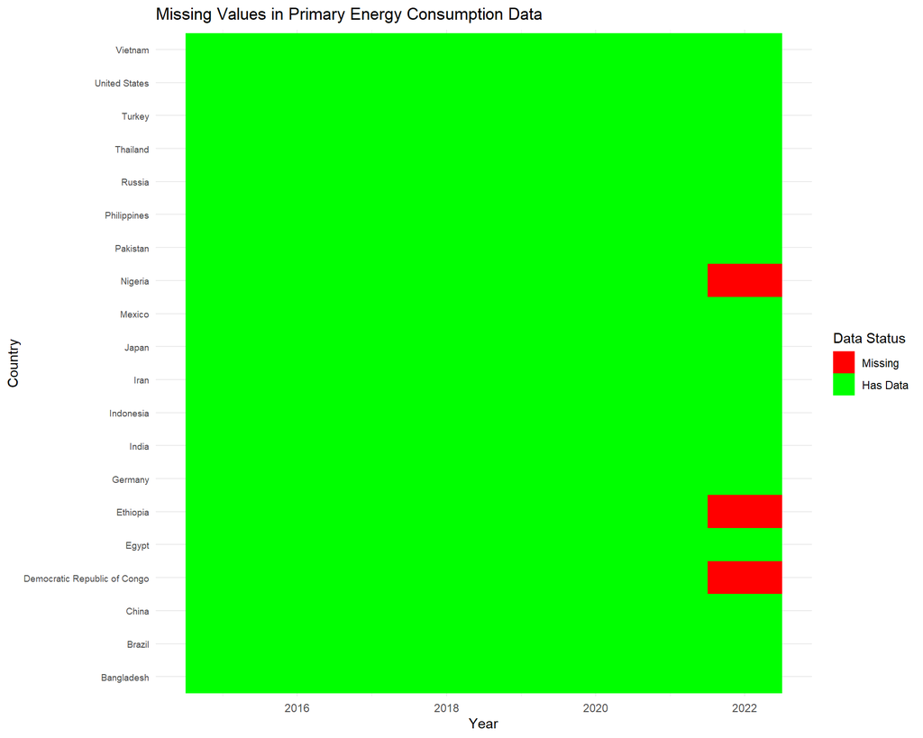

```r
# Create a heatmap of missing values by country and year
missing_pattern_plot <- function(data, value_col, title) {
  # Count missing values by country and year
  missing_by_country_year <- data %>%
    group_by(country, year) %>%
    summarize(missing_count = sum(is.na(!!sym(value_col))), .groups = 'drop') %>%
    mutate(has_data = missing_count == 0)

  # Create the plot
  p <- ggplot(missing_by_country_year, aes(x = year, y = country, fill = has_data)) +
    geom_tile() +
    scale_fill_manual(values = c("TRUE" = "green", "FALSE" = "red"),
                      labels = c("TRUE" = "Has Data", "FALSE" = "Missing"),
                      name = "Data Status") +
    labs(title = title,
         x = "Year",
         y = "Country") +
    theme_minimal() +
    theme(axis.text.y = element_text(size = 7))

  return(p)
}

# Limit to a subset of countries for better visualization (top 20 by population)
top_countries <- merged_data %>%
  filter(!is.na(population)) %>%
  group_by(country) %>%
  summarize(avg_pop = mean(population, na.rm = TRUE), .groups = 'drop') %>%
  arrange(desc(avg_pop)) %>%
  head(20) %>%
  pull(country)

# Create missing data pattern plots
merged_subset <- merged_data %>% filter(country %in% top_countries)

# Primary energy consumption missing pattern
primary_energy_plot <- missing_pattern_plot(
  merged_subset,
  "primary_energy_consumption",
  "Missing Values in Primary Energy Consumption Data"
)

# Emissions missing pattern
emissions_plot <- missing_pattern_plot(
  merged_subset,
  "emissions",
  "Missing Values in Emissions Data"
)

# Display the plots
primary_energy_plot
```

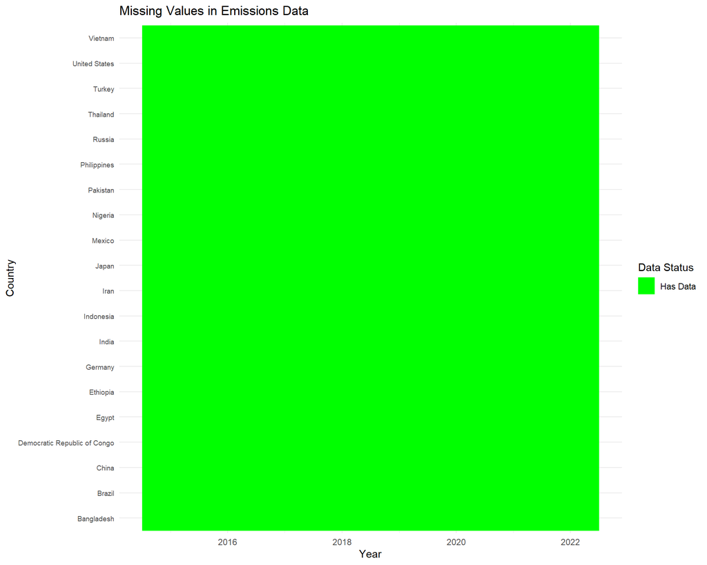

```r
emissions_plot
```

```r
# Save the plots
ggsave(file.path(plots_dir, "primary_energy_missing_pattern.png"), primary_energy_plot, width = 10, height = 8)
ggsave(file.path(plots_dir, "emissions_missing_pattern.png"), emissions_plot, width = 10, height = 8)
```

## Country-Specific Energy Mix Analysis

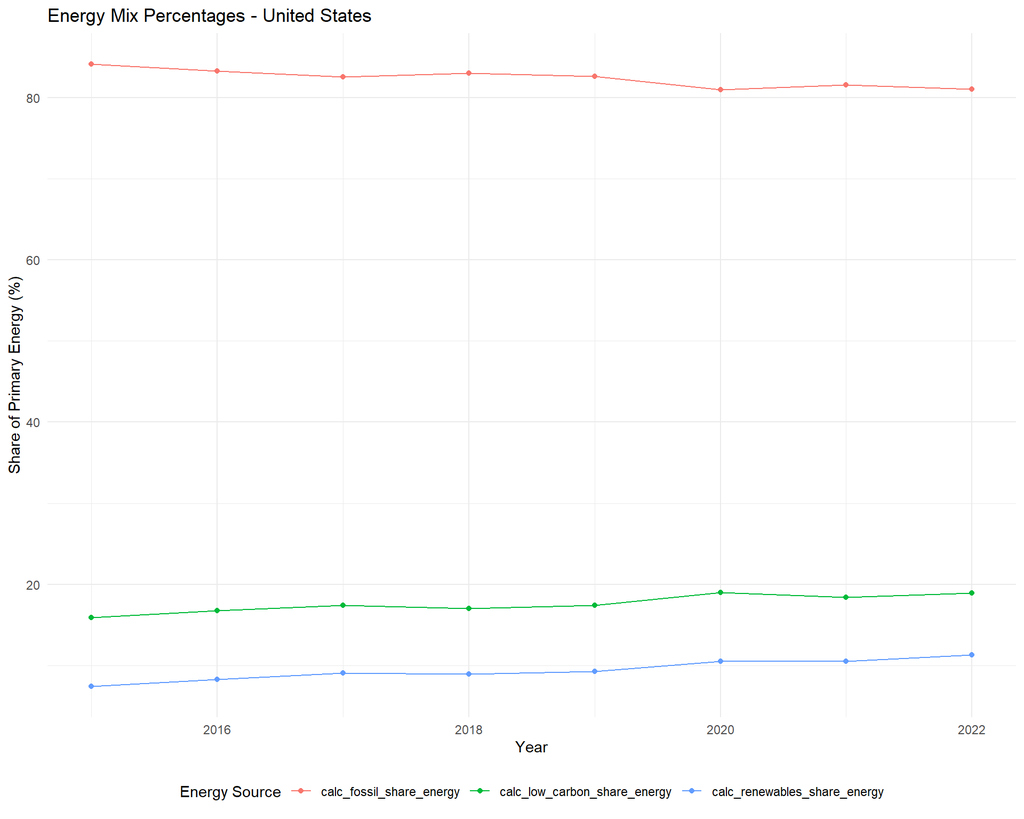

```r
# Function to create a line plot for a specific country over time
country_line_plot <- function(data, country_name, y_cols, title, y_lab) {
  # Filter for the specific country
  country_data <- data %>%
    filter(country == country_name) %>%
    arrange(year)

  # Reshape data to long format for plotting multiple lines
  plot_data <- country_data %>%
    select(year, all_of(y_cols)) %>%
    gather(key = "variable", value = "value", -year)

  # Create the plot
  p <- ggplot(plot_data, aes(x = year, y = value, color = variable)) +
    geom_line() +
    geom_point() +
    labs(title = paste(title, "-", country_name),
         x = "Year",
         y = y_lab,
         color = "Energy Source") +
    theme_minimal() +
    theme(legend.position = "bottom")

  return(p)
}

# Create energy mix plots for major countries
countries_to_plot <- c("United States", "China", "India", "Germany", "United Kingdom")

# Let's plot one example in the document
if ("United States" %in% merged_data$country) {
  # Energy consumption plot
  consumption_plot <- country_line_plot(
    merged_data,
    "United States",
    c("fossil_fuel_consumption", "low_carbon_consumption", "renewables_consumption"),
    "Energy Consumption Mix",
    "Energy Consumption (TWh)"
  )

  # Energy share plot
  share_plot <- country_line_plot(
    merged_data,
    "United States",
    c("calc_fossil_share_energy", "calc_low_carbon_share_energy", "calc_renewables_share_energy"),
    "Energy Mix Percentages",
    "Share of Primary Energy (%)"
  )

  # Display the plots
  consumption_plot
  share_plot
}
```

## Emissions vs. Energy Consumption

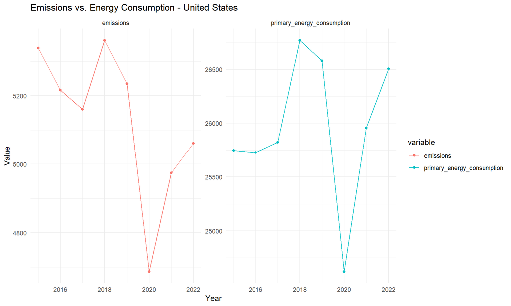

```r
# Example for United States
if ("United States" %in% merged_data$country) {
  # Emissions vs. energy plot
  emissions_energy_data <- merged_data %>%
    filter(country == "United States") %>%
    select(year, emissions, primary_energy_consumption) %>%
    gather(key = "variable", value = "value", -year)

  emissions_energy_plot <- ggplot(emissions_energy_data, aes(x = year, y = value, color = variable, group = variable)) +
    geom_line() +
    geom_point() +
    facet_wrap(~variable, scales = "free_y") +
    labs(title = paste("Emissions vs. Energy Consumption - United States"),
         x = "Year",
         y = "Value") +
    theme_minimal()

  emissions_energy_plot
}
```

## Global Energy Trends

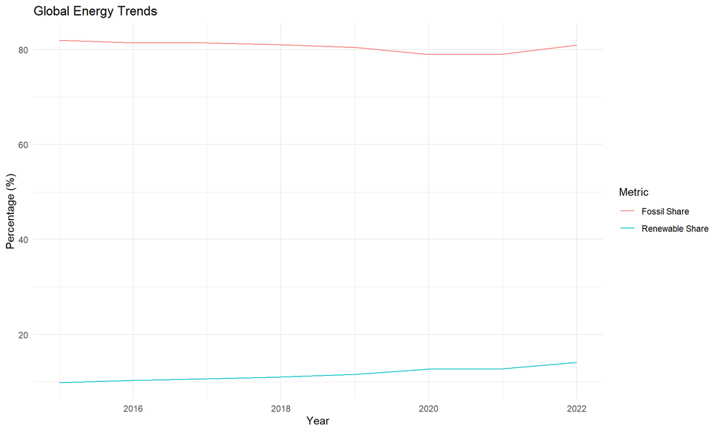

```r
# Global trends plot
global_data <- merged_data %>%
  group_by(year) %>%
  summarize(
    total_emissions = sum(emissions, na.rm = TRUE),
    total_energy = sum(primary_energy_consumption, na.rm = TRUE),
    fossil_share = sum(fossil_fuel_consumption, na.rm = TRUE) / sum(primary_energy_consumption, na.rm = TRUE) * 100,
    renewable_share = sum(renewables_consumption, na.rm = TRUE) / sum(primary_energy_consumption, na.rm = TRUE) * 100,
    .groups = 'drop'
  )

global_trends_plot <- ggplot(global_data, aes(x = year)) +
  geom_line(aes(y = fossil_share, color = "Fossil Share")) +
  geom_line(aes(y = renewable_share, color = "Renewable Share")) +
  labs(title = "Global Energy Trends",
       x = "Year",
       y = "Percentage (%)",
       color = "Metric") +
  theme_minimal()

global_trends_plot
```